# Prediction Assignment Writeup

Theoneste

10/13/2020

## Overview

This document is the final report of the Peer Assessment project from Coursera’s course Practical Machine Learning at Johns Hopkins University.

The goal of this project is to predict the manner in which they did the exercise. This is the “classe” variable in the training set. I have may use any of the other variables to predict with. I created this a report describing how i have built my model and how I used cross validation. Here is how I was expected out of sample error is, I used prediction model to predict 20 different test cases.

## Required Packages

Here are all packages i will need in this assignment and I want to setup the enviroment

```r
library(knitr)
library(caret)
```

```r
library(rpart)
library(e1071)
library(rpart.plot)
library(rattle)
library(randomForest)
library(corrplot)
set.seed(333)
```

## Getting Data and Loading Data

This is Data i have used in this assignment

```r
# Download the data
Trai_Url <- "https://d396qusza40orc.cloudfront.net/predmachlearn/pml-training.csv"
Tes_Url <- "https://d396qusza40orc.cloudfront.net/predmachlearn/pml-testing.csv"

download.file(Trai_Url, destfile = "pml-training.csv")

download.file(Tes_Url, destfile = "pml-testing.csv")

#Reading the Data
training <- read.table("pml-training.csv", sep = ",", header = TRUE)
testing <- read.table("pml-testing.csv", sep = ",", header = TRUE)
```

NOw we need to split the original training set into our training set and a validation set

```r
inTrain <- createDataPartition(y=training$classe, p=0.7, list=F)
trai_one <- training[inTrain, ]
trai_two <- training[-inTrain, ]
```

Now we may see the dimension of our data

```r
dim(trai_one)
```

```
## [1] 13737   160
```

```r
dim(trai_two)
```

```
## [1] 5885  160
```

As we see both datasets have 160 variables and trai_one has 13737 observations and trai_two has 5885 observations.

Now let us removes all near-zero variance predictors

```r
nzv <- nearZeroVar(training)
trai_one <- trai_one[, -nzv]
trai_two <- trai_two[, -nzv]
```

Removing with NA values

```r
trai_one <- trai_one[, colSums(is.na(trai_one)) == 0]
trai_two <- trai_two[, colSums(is.na(trai_two)) == 0]
```

Removing identification only variables (columns 1 to 5)

```r
trai_one <- trai_one[, -(1:5)]
trai_two  <- trai_two[, -(1:5)]
```

This correlation analysis between the variables is necessary before any analysis to avoid any unrelated conclusion

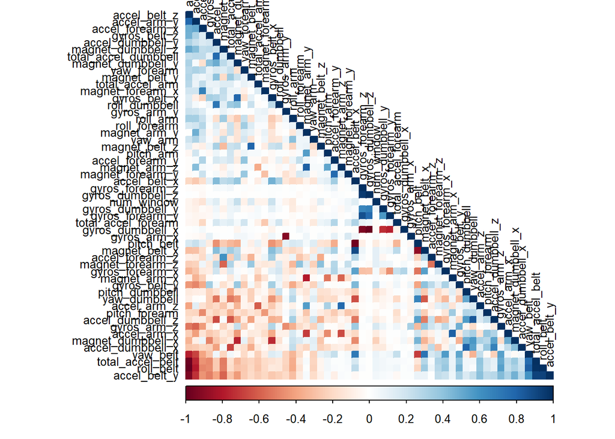

```r
corMatrix <- cor(trai_one[, -54])
corrplot(corMatrix, order = "FPC", method = "color", type = "lower", tl.cex = 0.8, tl.col = rgb(0, 0, 0))
```

The highly correlated variables are shown in dark colors in the graph above. To make an even more compact analysis, a PCA (Principal Components Analysis) could be performed as pre-processing step to the datasets. Nevertheless, as the correlations are quite few, this step will not be applied for this assignment.

## Choissing Model

```r
set.seed(1813)
model1 <- trainControl(method = "repeatedcv", number = 5, repeats = 2)
pred1  <- train(classe ~ ., data = trai_one, method = "rf",trControl = model1, verbose = FALSE)
pred1$finalModel
```

```
##
## Call:
##  randomForest(x = x, y = y, mtry = param$mtry, verbose = FALSE)
##                Type of random forest: classification
##                      Number of trees: 500
## No. of variables tried at each split: 27
##
##         OOB estimate of  error rate: 0.21%
## Confusion matrix:
##      A    B    C    D    E  class.error
## A 3904    1    0    0    1 0.0005120328
## B    6 2650    2    0    0 0.0030097818
## C    0    5 2391    0    0 0.0020868114
## D    0    0    6 2245    1 0.0031083481
## E    0    0    0    7 2518 0.0027722772
```